# Econometría 2

Juan David Rengifo Castro

2/10/2022

```r
ID <- 202026750003
```

# Quizes

## Quiz 1

Antes de empezar:

- En la línea del código de R donde dice ID deben poner su identificador personal, que corresponde a su código de estudiante. Los resultados del código dependen de este indicador, por lo que las respuestas correctas serán diferentes para cada estudiante.

Para este quiz vamos a usar los datos de precios de las acciones de S&P 500, y trataremos de estimar la relación entre una acción y el mercado.

### Punto 1

(*3 puntos*) Busque la acción UHS en [Wikipedia](https://en.wikipedia.org/wiki/List_of_S%26P_500_companies) y escriba el nombre de la empresa, el sector, la fecha en que se fundó y una breve descripción de ésta.

**Código:** (UHS)

**Sector:** Información y tecnología

**Fundación:** 1995

**Descripción:** [VERISIGN](https://www.verisign.com) es una compañia estadounidense que pertenece al sector de información y tecnología. Es un provedor mundial confiable y constante de dominios e infraestructura asociada al internet.

### Punto 2

(*5 puntos*) Grafique los rendimientos de UHS (ret) desde el 2016 hasta el 2021. Interprete lo que puede ver en la grafica. Explique los periodos de altos y bajos rendimientos

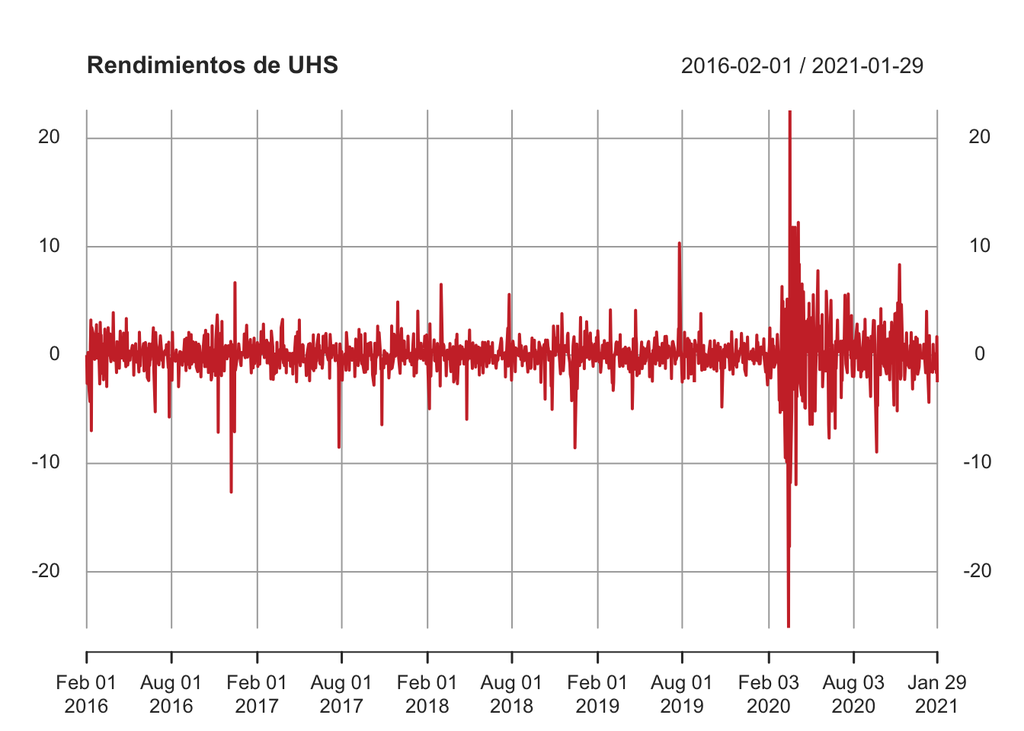

```r
plot(ret, main = paste("Rendimientos de", ticker[stock]), col = 'brown3')
```

A partir de la gráfica podemos observar que los rendimientos de UHS parecen tener media cero lo largo del tiempo, lo cual nos puede dar indicios de estacionareidad, algo deseado en el análisis de series de tiempo. No obstante, la varianza parece ser dinámica, indicando una no estacionareidad. El primer año los rendimientos presentan una volatilidad alta oscilando entre -5% y 5%, mientras que en el 2017 esta volatilidad disminuye a retornos entre -2% y 2%. El 2018 parece tomar un comporatmiento similar al del año 2016 y desde el 2019 hasta la fecha adopta rendimientos de hasta $\pm4\%$ con excepción de una muy alta volatilidad en el segundo trimestre del 2020 gracias al inicio de las medidas de mitigación de la pandemia por el COVID-19.

### Punto 3

(*15 puntos*) Estime una regresión MCO con el S&P 500 (sp1) como variable dependiente y UHS (ret) como variable independiente.

Según el modelo CAPM:

$\beta_j > 0$: significa que la tasa de retorno del activo 𝒋 está correlacionada positivamente con la tasa de retorno del mercado, por lo que entre más grande sea el beta, más riesgoso será el activo.

$\beta_j < 0$: Los activos con beta negativos ofrecen una forma de seguro contra la variabilidad de la tasa de retorno del mercado, pues están correlacionados negativamente.

Interprete el coeficiente estimado. ¿Tienen sentido económico estos resultados?

```r
reg <- lm(sp1 ~ ret)
summary(reg)
```

```
##
## Call:
## lm(formula = sp1 ~ ret)
##
## Residuals:
##     Min      1Q  Median      3Q     Max
## -6.9618 -0.3985  0.0322  0.4411  7.2170
##
## Coefficients:
##             Estimate Std. Error t value Pr(>|t|)
## (Intercept)  0.04922    0.02725   1.806   0.0711 .
## ret          0.31262    0.01169  26.731   <2e-16 ***
## ---
## Signif. codes:  0 '***' 0.001 '**' 0.01 '*' 0.05 '.' 0.1 ' ' 1
##
## Residual standard error: 0.9671 on 1257 degrees of freedom
## Multiple R-squared:  0.3624, Adjusted R-squared:  0.3619
## F-statistic: 714.6 on 1 and 1257 DF,  p-value: < 2.2e-16
```

Cabe resaltar, que esta estimación está asociada con un comporamiento que tiene sentido económico. VERISIGN al tener una baja influencia en el mercado por su pequeña participación en el sector, podría considerarse una empresa seguidora y por tanto, sus rendimientos estarían correlacionados positivamente con la tasa de retorno del mercado, tal y como lo indica la interpretación de nuestra estimación por OLS.

### Punto 4

(*7 puntos*) Dado que estamos trabajando con datos de tipo financiero, ¿Considera usted que puede existir correlación serial en estos datos? ¿Sí, no, por qué?.

Es posible que no exista correlación serial dado que al ser variable de tipo financiero es plausible que el supuesto de mercado eficiente se cumpla, es decir, que el precio del activo refleja toda la información disponible del mismo. Esto implica que no hay activos sobrevalorados y subvalorados puesto que el precio se ajusta instantaneamente evitando que se puedan obtener beneficios. Para que esto se cumpla es necesario que no hayan costes de transacción o de información, lo cual no siempre se cumple, en especial para inversores extranjeros. Así que es posible que la hipótesis de mercado eficiente no aplique y por tanto exista correlación serial. No obstante, dichos costos puede ser menospreciables y así la hipótesis puede ser válida al menos en su versión más débil.

**Fuente:** [Economipedia](https://economipedia.com/definiciones/hipotesis-del-mercado-eficiente.html).

### Punto 5

(*10 puntos*) Estime la regresión del punto (3) usando MCG con correlación AR1. Interprete los coeficientes. ¿En que cambia la interpretación del punto 2?

```r
aux.data <- data.frame(ret, sp1)
names(aux.data) <- c("Stock", "SP500")
reg.mcg <- nlme::gls(SP500 ~ Stock, data = aux.data, correlation = corAR1())
summary(reg.mcg)
```

```
## Generalized least squares fit by REML
##   Model: SP500 ~ Stock
##   Data: aux.data
##        AIC      BIC    logLik
##   3461.817 3482.363 -1726.909
##
## Correlation Structure: AR(1)
##  Formula: ~1
##  Parameter estimate(s):
##        Phi
## -0.1905744
##
## Coefficients:
##                  Value  Std.Error  t-value p-value
## (Intercept) 0.04949325 0.02248416  2.20125  0.0279
## Stock       0.29909969 0.01152733 25.94700  0.0000
##
##  Correlation:
##       (Intr)
## Stock -0.004
##
## Standardized residuals:
##         Min          Q1         Med          Q3         Max
## -7.33419129 -0.40812504  0.03066248  0.45695496  7.53182734
##
## Residual standard error: 0.9674321
## Degrees of freedom: 1259 total; 1257 residual
```

```r
intervals(reg.mcg, level = 0.99)
```

```
## Approximate 99% confidence intervals
##
##  Coefficients:
##                    lower       est.     upper
## (Intercept) -0.008510178 0.04949325 0.1074967
## Stock        0.269362098 0.29909969 0.3288373
## attr(,"label")
## [1] "Coefficients:"
##
##  Correlation structure:
##          lower       est.      upper
## Phi -0.2615918 -0.1905744 -0.1175045
## attr(,"label")
## [1] "Correlation structure:"
##
##  Residual standard error:
##     lower      est.     upper
## 0.9173073 0.9674321 1.0202959
```

A partir de la estimación por intervalos, observamos que no se incluye al cero con un nivel de confianza de 0.99, lo cual indica que usar un AR(1) es acertado.

### Punto 6

(*10 puntos*) ¿Cuál modelo considera usted es correcto de todos los estimados?. ¿Por qué?

Para contestar esta pregunta, conviene analizar los residuales de MCO, si estos muestran evidencia de correlación serial y son un AR(1), conviene usar un modelo MCG con AR(1), de lo contrario el MCO seria ideal.

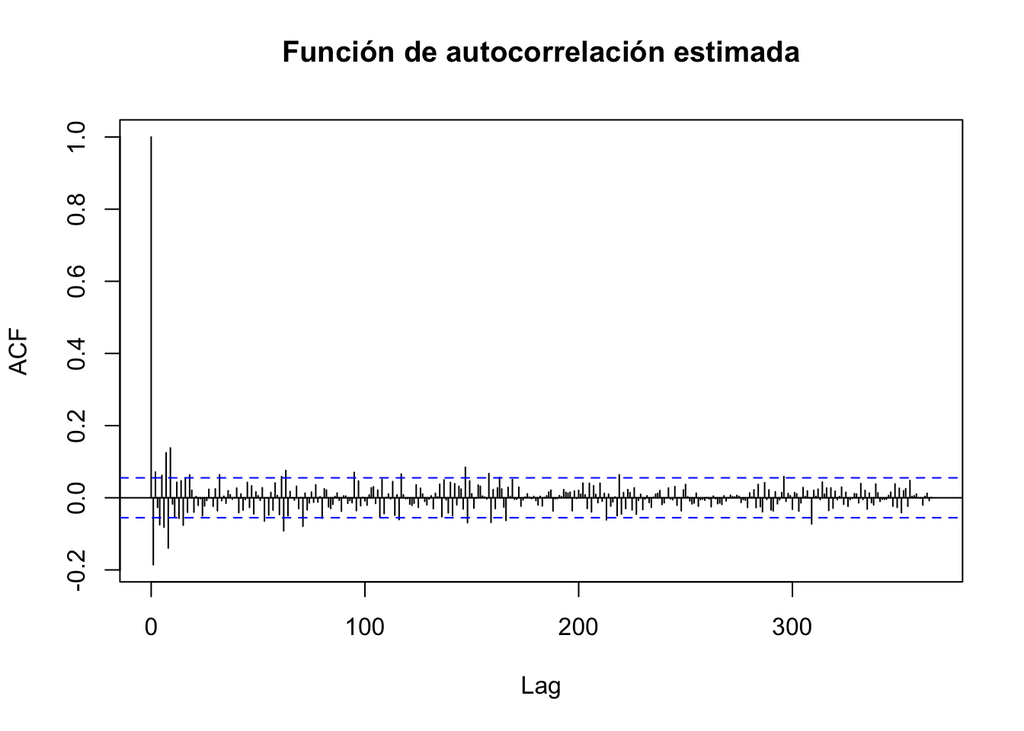

```r
acf(reg$residuals, lag.max = 365,
    main = "Función de autocorrelación estimada")
```

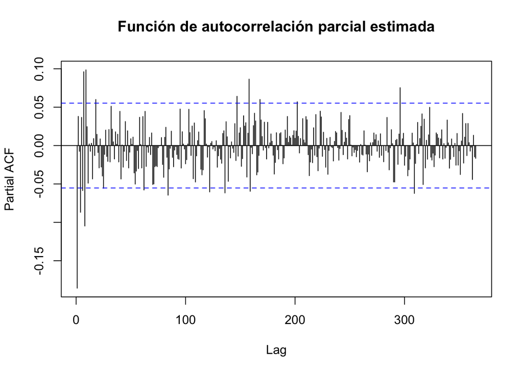

```r
pacf(reg$residuals, lag.max = 365,
     main = "Función de autocorrelación parcial estimada")
```

Pese a que puede quedar en duda si el error debia modelarse con un AR(1), es claro, que existe correlación serial en los residuales de mco, lo cuál se verifica con el test de Breush-Godfrey para todos los niveles de significancia tradicionales incluso para un solo rezago.

```r
checkresiduals(reg, lag = 1, plot = F)
```

```
##
##  Breusch-Godfrey test for serial correlation of order up to 1
##
## data:  Residuals
## LM test = 43.847, df = 1, p-value = 3.55e-11
```

```r
checkresiduals(reg, lag = 10, plot = F)
```

```
##
##  Breusch-Godfrey test for serial correlation of order up to 10
##
## data:  Residuals
## LM test = 100.28, df = 10, p-value < 2.2e-16
```

Finalmente, al comparar el criterio de información bayesiano (BIC), vemos que el MCG otorga ligeros mejores resultados. Así las cosas, pese a que las estimaciones puntuales, la significancia y el BIC no son muy distintas. Es claro que los supuestos de MCO se violan y por tanto, conviene usar otros modelos como el mcg con AR(1), entendiendo que los residuales de MCO parecen ser un AR(1) a partir del análisis gráfico.

```r
data.frame(mco = BIC(reg), mcg = BIC(reg.mcg), row.names = c("BIC"))
```

```
##          mco      mcg
## BIC 3507.952 3482.363
```

### Preguntas

1. ¿Cómo se calculan los retornos?
2. ¿Por qué son cercanos a cero si el precio de la acción casi que ha triplicado su valor desde el 2016?

# Modelos de series de tiempo

## Resumen

[output not shown]